# Math 421 - Midterm

## II. Data Visualization

Continue with the data from part I.

1. Provides at least 10 meaningful plots. Comments on the plots. All plots should have title, caption, appropriate labels on x and y-axis

```r
library(ggplot2)
library(dplyr)
library(gganimate)
library(gifski)
# Create month labels
df_clean <- df_clean %>% mutate(Month = factor(moa, levels = 1:12,
labels = month.name), Gender = factor(sex, levels = c("1", "2"),
labels = c("Male", "Female")))
```

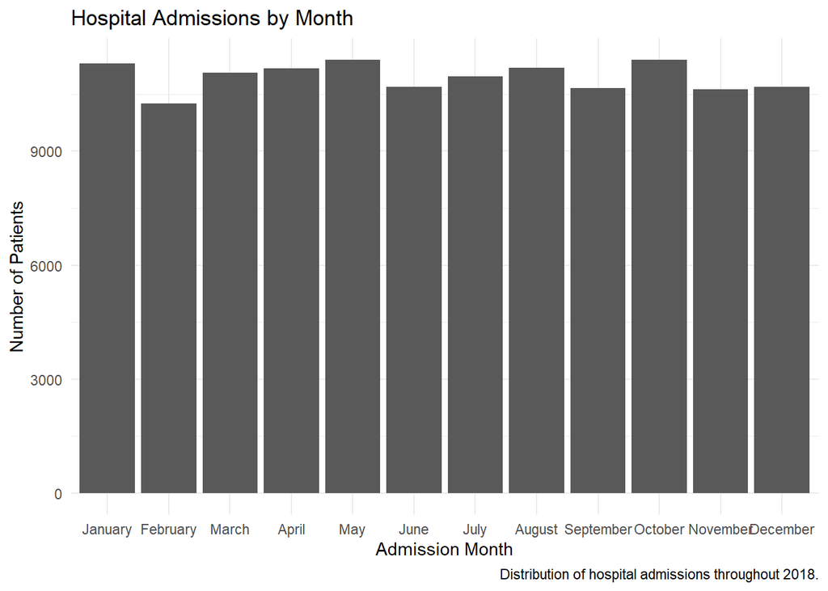

```r
# plot 1
ggplot(df_clean, aes(x = Month)) + geom_bar() +

labs(title = "Hospital Admissions by Month", x = "Admission Month",    y = "Number of Patients", caption = "Distribution of hospital admissions throughout 2018.") + theme_minimal()
```

```r
ggsave("plot1.png", width = 10, height = 6)
```

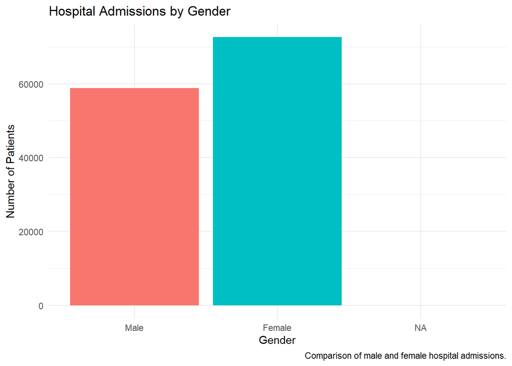

```r
# plot 2
ggplot(df_clean, aes(x = Gender, fill = Gender)) + geom_bar() +

labs(title = "Hospital Admissions by Gender", x = "Gender",
y = "Number of Patients", caption = "Comparison of male and female hospital admissions.") + theme_minimal() + theme(legend.position = "none")
```

```r
ggsave("plot2.png")
```

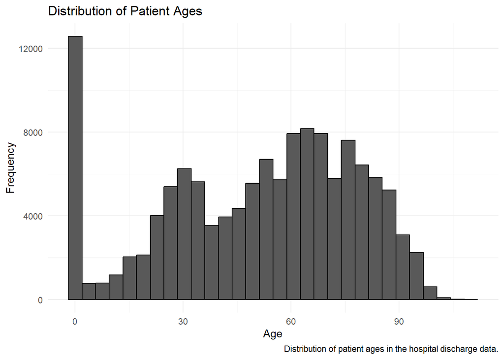

```r
# plot 3
ggplot(df_clean, aes(x = age)) + geom_histogram(bins = 30, color = "black") +

labs(title = "Distribution of Patient Ages", x = "Age",                y = "Frequency", caption = "Distribution of patient ages in the hospital discharge data.") + theme_minimal()
```

```r
ggsave("plot3.png")
```

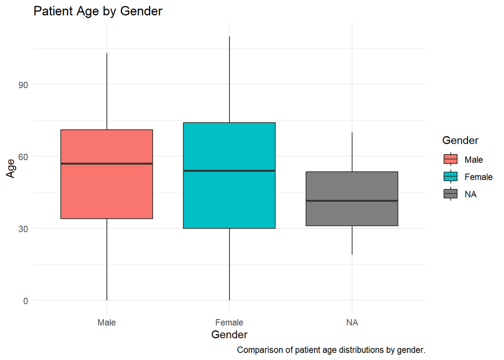

```r
# plot 4
ggplot(df_clean, aes(x = Gender, y = age, fill = Gender)) + geom_boxplot() +

labs(title = "Patient Age by Gender", x = "Gender", y = "Age",
caption = "Comparison of patient age distributions by gender.") +
theme_minimal()
```

```r
ggsave("plot4.png")
```

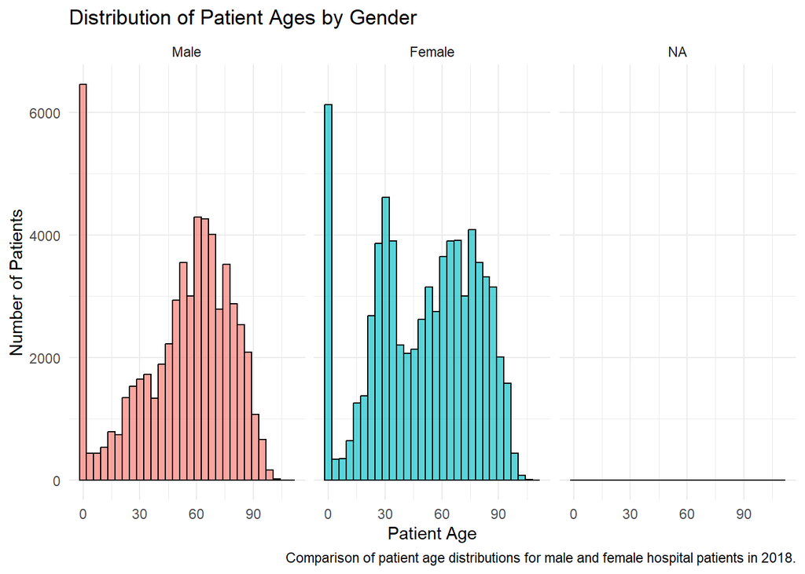

```r
# plot 5
ggplot(df_clean, aes(x = age, fill = Gender)) + geom_histogram(
bins = 30, alpha = 0.65, position = "identity", color = "black") +
facet_wrap(~ Gender) +

  labs(title = "Distribution of Patient Ages by Gender", x = "Patient Age", y = "Number of Patients", fill = "Gender",
caption = "Comparison of patient age distributions for male and female hospital patients in 2018.") + theme_minimal() +
  theme(legend.position = "none")
```

```r
# save graph
ggsave("plot5.png", width = 10, height = 6)
```

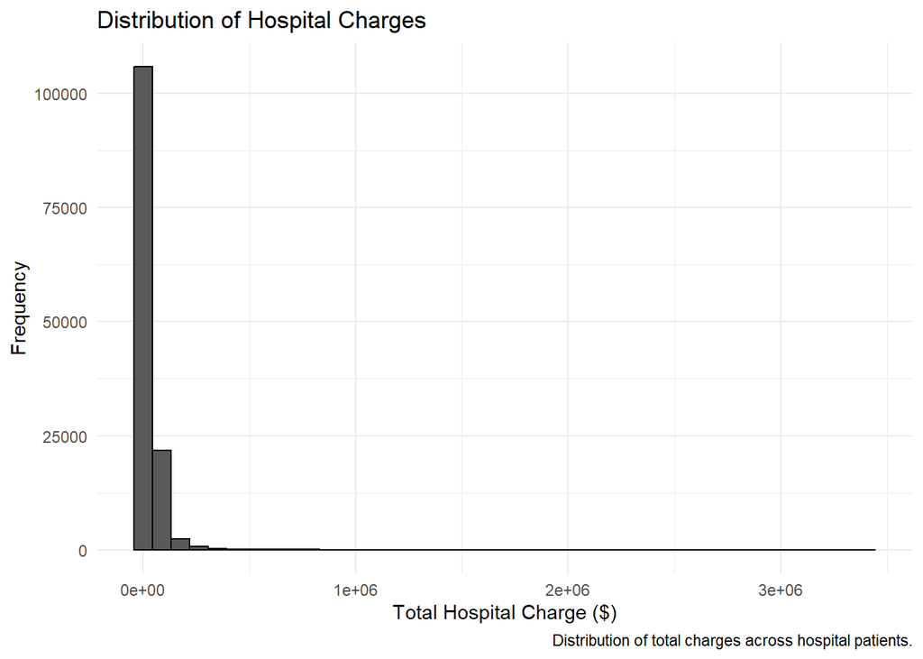

```r
# plot 6
ggplot(df_clean, aes(x = tot)) + geom_histogram(bins = 40, color = "black") +

labs(title = "Distribution of Hospital Charges", x = "Total Hospital Charge ($)", y = "Frequency", caption = "Distribution of total charges across hospital patients.") + theme_minimal()
```

```r
ggsave("plot6.png")
```

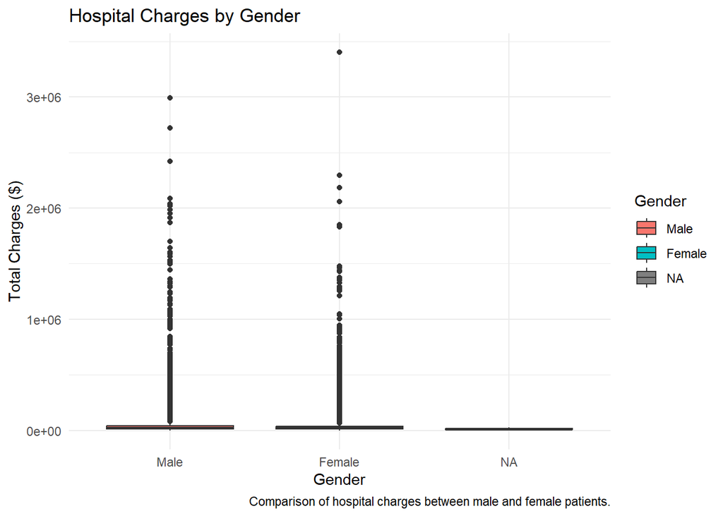

```r
# plot 7
ggplot(df_clean, aes(x = Gender, y = tot, fill = Gender)) + geom_boxplot() +

labs(title = "Hospital Charges by Gender", x = "Gender",
y = "Total Charges ($)",
caption = "Comparison of hospital charges between male and female patients.") + theme_minimal()
```

```r
ggsave("plot7.png")
```

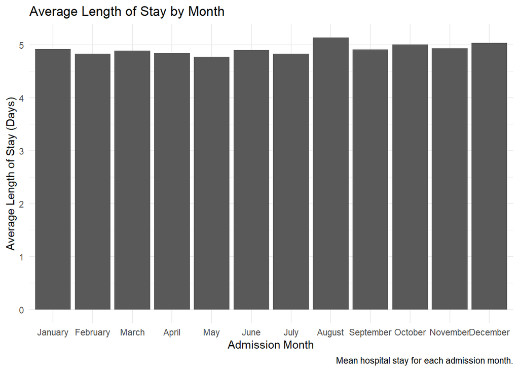

```r
# plot 8
ggplot(df_clean, aes(x = Month, y = los)) + stat_summary(fun = mean,
geom = "bar") +

labs(title = "Average Length of Stay by Month", x = "Admission Month",
y = "Average Length of Stay (Days)", caption = "Mean hospital stay for each admission month.") + theme_minimal()
```

```r
ggsave("plot8.png")
```

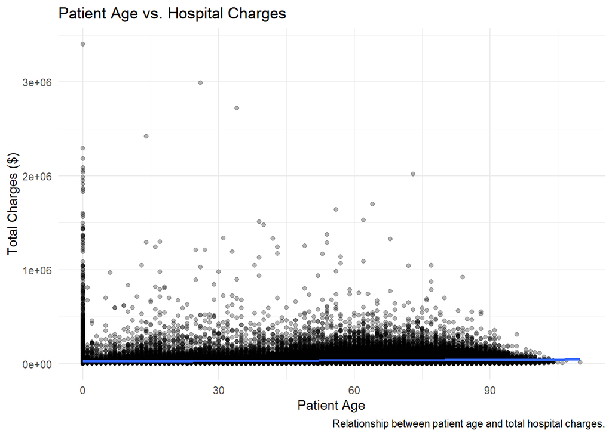

```r
# plot 9
ggplot(df_clean, aes(x = age, y = tot)) + geom_point(alpha = 0.3) +
geom_smooth(method = "lm", se = FALSE) +

labs(title = "Patient Age vs. Hospital Charges", x = "Patient Age",
y = "Total Charges ($)", caption = "Relationship between patient age and total hospital charges.") + theme_minimal()
```

```r
ggsave("plot9.png")
```

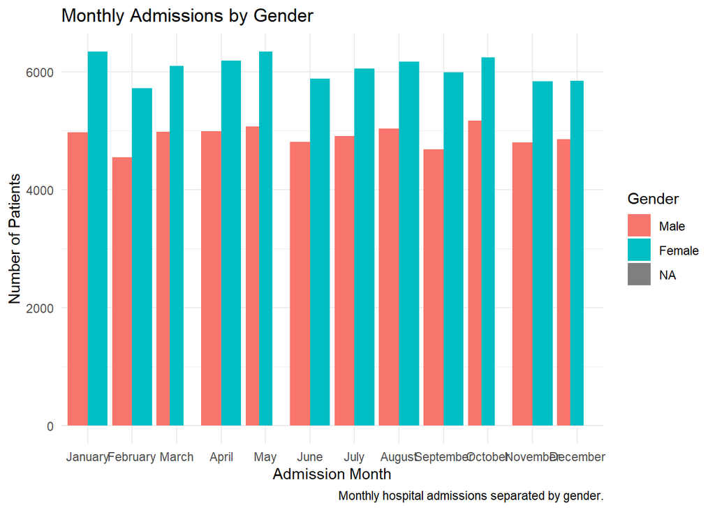

```r
# plot 10
ggplot(df_clean, aes(x = Month, fill = Gender)) + geom_bar(position = "dodge") +

labs(title = "Monthly Admissions by Gender", x = "Admission Month",
y = "Number of Patients", fill = "Gender",
caption = "Monthly hospital admissions separated by gender.") +
theme_minimal()
```

```r
ggsave("plot10.png")
```

2. Make an animation plot.

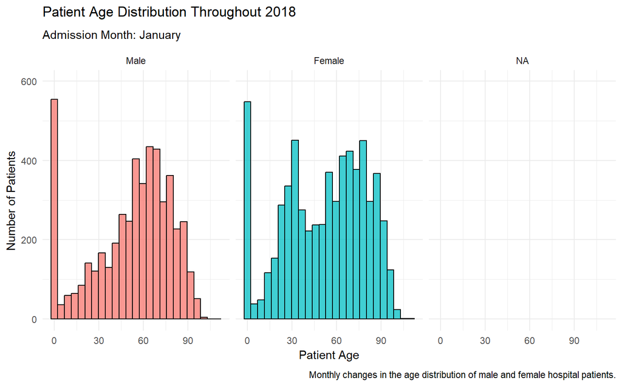

```r
# animation
age_animation <- ggplot(df_clean, aes(x = age, fill = Gender)
) + geom_histogram(bins = 25, color = "black", alpha = 0.75) +
facet_wrap(~ Gender) + labs(title = "Patient Age Distribution Throughout 2018", subtitle = "Admission Month: {closest_state}",
x = "Patient Age", y = "Number of Patients",
caption = "Monthly changes in the age distribution of male and female hospital patients.") +

transition_states(Month, transition_length = 2, state_length = 1) +
ease_aes("cubic-in-out") + theme_minimal() + theme(legend.position = "none")

age_gif <- animate(age_animation, nframes = 144, fps = 12,         width = 8, height = 5)

age_gif
```

```r
# save animation
anim_save("patient_age_by_gender.gif", animation = age_gif)
```

3. Write a paragraph to summarize the section and give your comments on the results.

```r
# One interesting finding from the age distributions is the noticeable increase in hospital admissions around age 30. In Graph 3, the overall age distribution shows a spike in this age range, suggesting that patients around this age are admitted to the hospital more frequently than some of the surrounding age groups in a way that is abnormal for such a distribution. One possible explanation for this pattern is pregnancy-related hospital visits, since women in their late twenties and early thirties are more likely to have hospital admissions associated with pregnancy and childbirth. This hypothesis is further supported by Graph 5, which separates the age distributions by gender. The increase around age 30 is almost exclusive to the female distribution. This difference suggests that the increase in admissions around this age may be driven largely by female patients and is consistent with the possibility that pregnancy-related admissions contribute to the pattern observed in Graph 3. Although the data does not directly identify pregnancy as the reason for these admissions, the comparison between the two gender distributions provides evidence supporting this hypothesis and demonstrates how separating the data into different groups can reveal patterns that are less obvious when looking at the overall population.
```

## III. Predictive Models

Continue with the data from part I. Make sure you do not have any missing values in the data. Use the follows as the target and input variables:

*Target Variable*: Create the target variable taking value of

- `low` if the total charge of a patient (`tot`) is smaller than the median of the total charge, and
- `high` otherwise.

*Input Variables*:

- “age”,“sex”,“raceethn”,“provider”,“moa”,“mod”,“admtype”,“campus”, ‘los’
1. Use `filter` function to filter out rows where `raceethn==''` or `admtype==''`. Make sure all the categorical variables are factor, numeric variables are numeric. Set Training : Testing Split = 10 : 90

```r
library(caret)
library(rpart)
library(rpart.plot)
library(ranger)

model_data <- df_clean %>% filter(raceethn != "", admtype != "") %>% select(tot, age, sex, raceethn, provider, moa, mod, admtype, campus, los)

# convert
categorical_vars <- c("sex", "raceethn", "provider",
                      "moa", "mod", "admtype", "campus")

model_data <- model_data %>% mutate(across(all_of(categorical_vars), as.factor), across(c(tot, age, los), as.numeric))

model_data <- model_data %>% filter(if_all(everything(), ~ !is.na(.x))) %>% filter(is.finite(tot), is.finite(age), is.finite(los))

# calculate median charge
median_charge <- median(model_data$tot)

# create target variable
model_data <- model_data %>% mutate(target = factor(if_else(tot < median_charge, "low", "high"), levels = c("low", "high")))

# prevent leakage
model_data <- model_data %>%
  select(-tot)

# split
set.seed(123)

trainIndex <- createDataPartition(model_data$target, p = 0.10,
list = FALSE)

train_data <- model_data[trainIndex, ]
test_data <- model_data[-trainIndex, ]

# check results
cat("Median Hospital Charge:", median_charge, "\n")
```

```
## Median Hospital Charge: 22124
```

```r
dim(train_data)
```

```
## [1] 12754    10
```

```r
dim(test_data)
```

```
## [1] 114773     10
```

```r
table(train_data$target)
```

```
##
##  low high
## 6377 6377
```

```r
table(test_data$target)
```

```
##
##   low  high
## 57385 57388
```

```r
sum(is.na(model_data))
```

```
## [1] 0
```

2. Train a decision tree using `rpart`. Plot the decision tree. Plot the variable importance ranked by the tree.

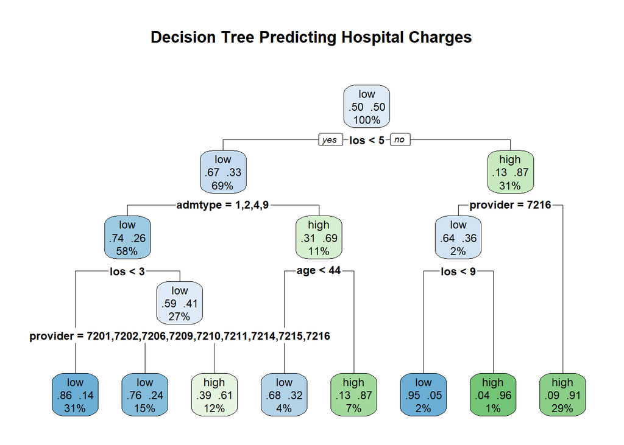

```r
set.seed(123)

tree_model <- rpart(target ~ ., data = train_data, method = "class",
control = rpart.control(cp = 0.01, minsplit = 20))

# plot
rpart.plot(tree_model, main = "Decision Tree Predicting Hospital Charges", type = 2, extra = 104, fallen.leaves = TRUE)
```

```r
# variable importance
importance <- data.frame(Variable = names(tree_model$variable.importance),
Importance = as.numeric(tree_model$variable.importance)) %>%
  arrange(desc(Importance))

print(importance)
```

```
##   Variable  Importance
## 1      los 1982.122104
## 2  admtype  515.740440
## 3 provider  512.605478
## 4      age  262.622828
## 5   campus  144.022436
## 6 raceethn   27.249337
## 7      sex    5.747264
## 8      mod    3.631862
```

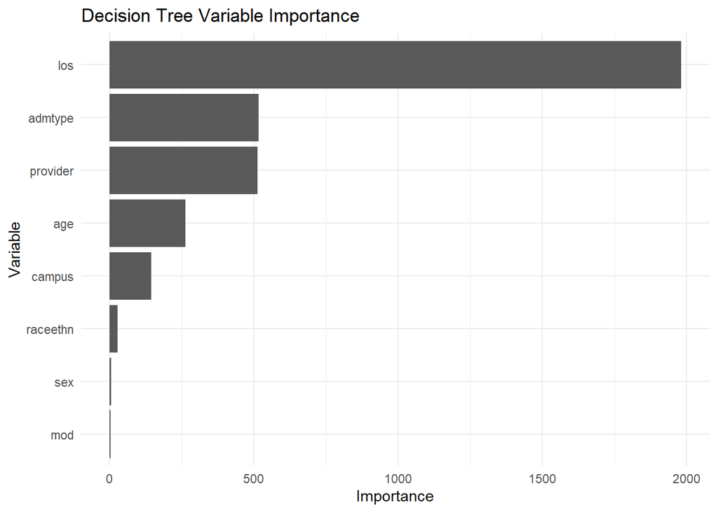

```r
# plot
ggplot(importance, aes(x = reorder(Variable, Importance),
y = Importance)) + geom_col() + coord_flip() + labs(
title = "Decision Tree Variable Importance", x = "Variable",
y = "Importance") + theme_minimal()
```

3. Using caret for this question. Set `Training Control` to be: Use Cross-Validation of 5 folds across all models. Train & tune at least 2 different models (i.e. two different values for `method=` in the train function of caret). Plot the hyper-parameter tuning plots for each model.

```r
# five fold
trControl <- trainControl(method = "cv", number = 5)

# decision tree
set.seed(123)

caret_tree <- train(target ~ ., data = train_data, method = "rpart",
trControl = trControl, tuneLength = 10,metric = "Accuracy")

print(caret_tree)
```

```
## CART
##
## 12754 samples
##     9 predictor
##     2 classes: 'low', 'high'
##
## No pre-processing
## Resampling: Cross-Validated (5 fold)
## Summary of sample sizes: 10203, 10204, 10203, 10204, 10202
## Resampling results across tuning parameters:
##
##   cp           Accuracy   Kappa
##   0.002090847  0.8278197  0.6556395
##   0.002979457  0.8240553  0.6481107
##   0.004077152  0.8200567  0.6401157
##   0.004390779  0.8185669  0.6371362
##   0.008624745  0.8164501  0.6328999
##   0.010976948  0.8059448  0.6118906
##   0.013877999  0.7974013  0.5948030
##   0.026187863  0.7835993  0.5671971
##   0.081072605  0.7493343  0.4986685
##   0.462599969  0.6879466  0.3759869
##
## Accuracy was used to select the optimal model using the largest value.
## The final value used for the model was cp = 0.002090847.
```

```r
caret_tree$bestTune
```

```
##            cp
## 1 0.002090847
```

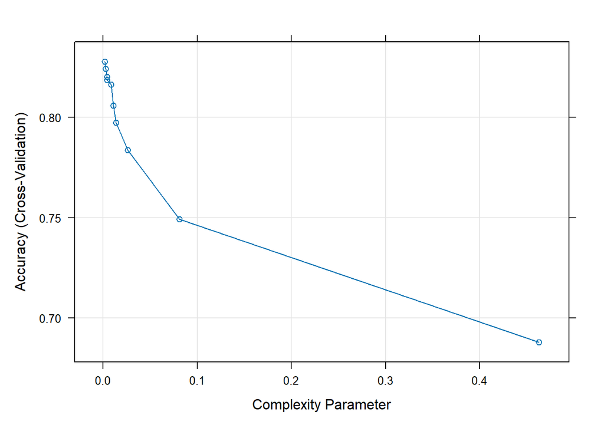

```r
# plot
plot(caret_tree)
```

```r
# random forest
set.seed(123)

caret_forest <- train(target ~ ., data = train_data, method = "ranger",
trControl = trControl, tuneLength = 5, metric = "Accuracy",
importance = "impurity")

print(caret_forest)
```

```
## Random Forest
##
## 12754 samples
##     9 predictor
##     2 classes: 'low', 'high'
##
## No pre-processing
## Resampling: Cross-Validated (5 fold)
## Summary of sample sizes: 10203, 10204, 10203, 10204, 10202
## Resampling results across tuning parameters:
##
##   mtry  splitrule   Accuracy   Kappa
##    2    gini        0.7744242  0.5488525
##    2    extratrees  0.6780636  0.3561248
##   14    gini        0.8297011  0.6594032
##   14    extratrees  0.8183321  0.6366653
##   26    gini        0.8202138  0.6404287
##   26    extratrees  0.8198215  0.6396440
##   38    gini        0.8155093  0.6310198
##   38    extratrees  0.8184885  0.6369781
##   51    gini        0.8129215  0.6258442
##   51    extratrees  0.8137053  0.6274112
##
## Tuning parameter 'min.node.size' was held constant at a value of 1
## Accuracy was used to select the optimal model using the largest value.
## The final values used for the model were mtry = 14, splitrule = gini
##  and min.node.size = 1.
```

```r
caret_forest$bestTune
```

```
##   mtry splitrule min.node.size
## 3   14      gini             1
```

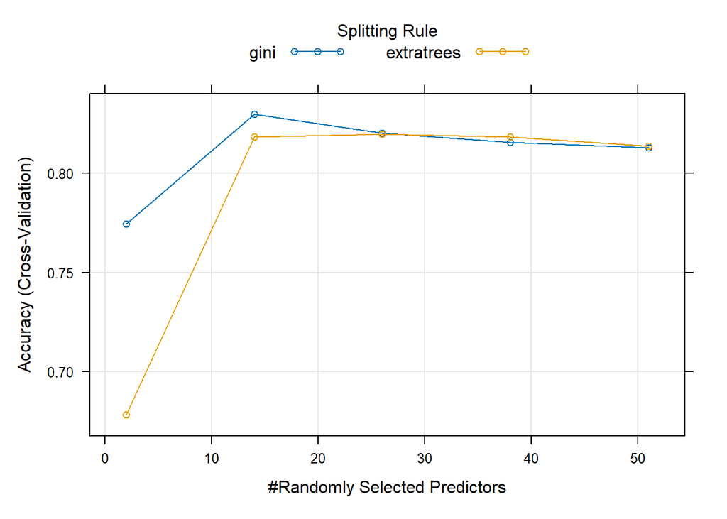

```r
# plot
plot(caret_forest)
```

4. Plot the comparison of the models in 3.

```r
# compare
model_results <- resamples(list("Decision Tree" = caret_tree,
"Random Forest" = caret_forest))

summary(model_results)
```

```
##
## Call:
## summary.resamples(object = model_results)
##
## Models: Decision Tree, Random Forest
## Number of resamples: 5
##
## Accuracy
##                    Min.   1st Qu.    Median      Mean   3rd Qu.      Max. NA's
## Decision Tree 0.8177900 0.8227451 0.8302626 0.8278197 0.8330067 0.8352941    0
## Random Forest 0.8176471 0.8228840 0.8310466 0.8297011 0.8345747 0.8423529    0
##
## Kappa
##                    Min.   1st Qu.    Median      Mean   3rd Qu.      Max. NA's
## Decision Tree 0.6355799 0.6454902 0.6605343 0.6556395 0.6660047 0.6705882    0
## Random Forest 0.6352941 0.6457680 0.6621023 0.6594032 0.6691456 0.6847059    0
```

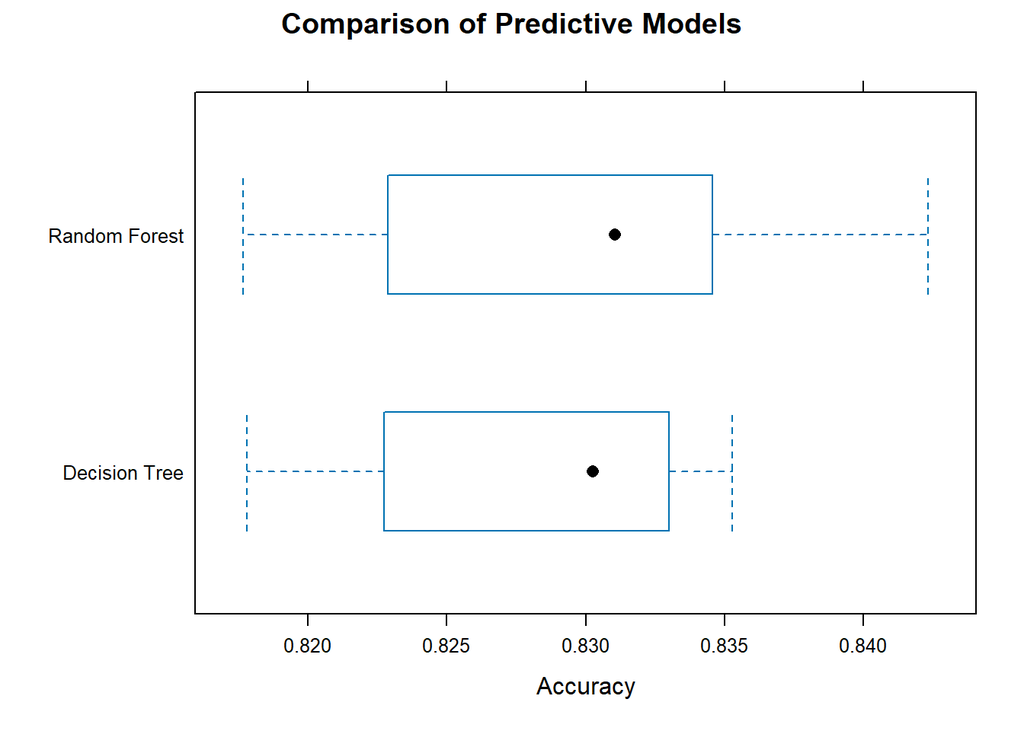

```r
# boxplot
bwplot(model_results, metric = "Accuracy", main = "Comparison of Predictive Models")
```

```r
# compare accuracy
comparison <- data.frame(Model = c("Decision Tree", "Random Forest"),
Average_Accuracy = c(max(caret_tree$results$Accuracy),
max(caret_forest$results$Accuracy)))

print(comparison)
```

```
##           Model Average_Accuracy
## 1 Decision Tree        0.8278197
## 2 Random Forest        0.8297011
```

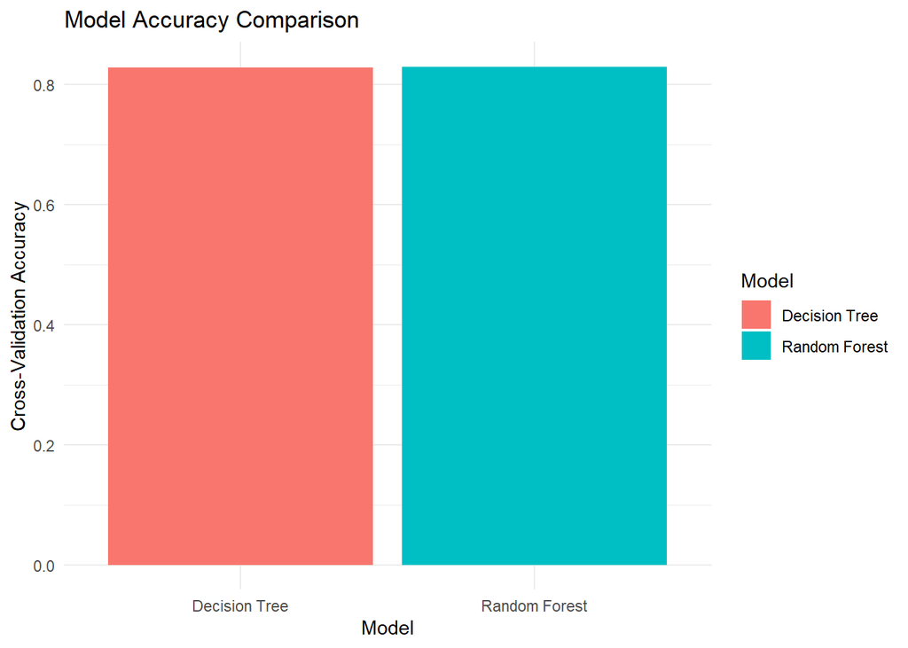

```r
# visual
ggplot(comparison,
aes(x = Model, y = Average_Accuracy, fill = Model)) +
geom_col() +

labs(title = "Model Accuracy Comparison", x = "Model", y = "Cross-Validation Accuracy") + theme_minimal()
```

5. What is your final selection for the model? Test the accuracy of your final model on the test data.

```r
# compare accuracy
tree_accuracy <- max(caret_tree$results$Accuracy)
forest_accuracy <- max(caret_forest$results$Accuracy)

# select best
if (tree_accuracy >= forest_accuracy) {final_model <- caret_tree
final_model_name <- "Decision Tree"} else {
final_model <- caret_forest
final_model_name <- "Random Forest"}

cat("Selected model:", final_model_name, "\n")
```

```
## Selected model: Random Forest
```

```r
# predict
predictions <- predict(final_model, newdata = test_data)

# confusion matrix
cm <- confusionMatrix(data = predictions, reference = test_data$target)

print(cm)
```

```
## Confusion Matrix and Statistics
##
##           Reference
## Prediction   low  high
##       low  48343 10545
##       high  9042 46843
##
##                Accuracy : 0.8293
##                  95% CI : (0.8272, 0.8315)
##     No Information Rate : 0.5
##     P-Value [Acc > NIR] : < 2.2e-16
##
##                   Kappa : 0.6587
##
##  Mcnemar's Test P-Value : < 2.2e-16
##
##             Sensitivity : 0.8424
##             Specificity : 0.8163
##          Pos Pred Value : 0.8209
##          Neg Pred Value : 0.8382
##              Prevalence : 0.5000
##          Detection Rate : 0.4212
##    Detection Prevalence : 0.5131
##       Balanced Accuracy : 0.8293
##
##        'Positive' Class : low
##
```

```r
# accuracy
cat("Testing Accuracy:", round(cm$overall["Accuracy"] * 100, 2), "%\n")
```

```
## Testing Accuracy: 82.93 %
```

6. Create another `target` variable (binary), decide the input variables and redo 1 to 5.

```r
# create second
model_data2 <- df_clean %>%
  filter(raceethn != "", admtype != "") %>%
  select(age, sex, raceethn, provider, moa, mod,
         admtype, campus, los)

# convert
model_data2 <- model_data2 %>%
  mutate(
    across(c(sex, raceethn, provider, moa, mod,
             admtype, campus), as.factor),
    across(c(age, los), as.numeric)
  )

# remove missing
model_data2 <- model_data2 %>%
  filter(if_all(everything(), ~ !is.na(.x))) %>%
  filter(is.finite(age), is.finite(los))

# calculate median length of stay
median_los <- median(model_data2$los)

# create binary target variable
model_data2 <- model_data2 %>%
  mutate(
    target = factor(
      if_else(los < median_los, "short", "long"),
      levels = c("short", "long")
    )
  )

# remove original los variable
model_data2 <- model_data2 %>%
  select(-los)

# split
set.seed(123)

trainIndex2 <- createDataPartition(
  model_data2$target,
  p = 0.10,
  list = FALSE
)

train_data2 <- model_data2[trainIndex2, ]
test_data2 <- model_data2[-trainIndex2, ]

# check results
cat("Median Length of Stay:", median_los, "\n")
```

```
## Median Length of Stay: 3
```

```r
dim(train_data2)
```

```
## [1] 12754     9
```

```r
dim(test_data2)
```

```
## [1] 114773      9
```

```r
table(train_data2$target)
```

```
##
## short  long
##  4849  7905
```

```r
table(test_data2$target)
```

```
##
## short  long
## 43632 71141
```

```r
# check missing values
sum(is.na(model_data2))
```

```
## [1] 0
```

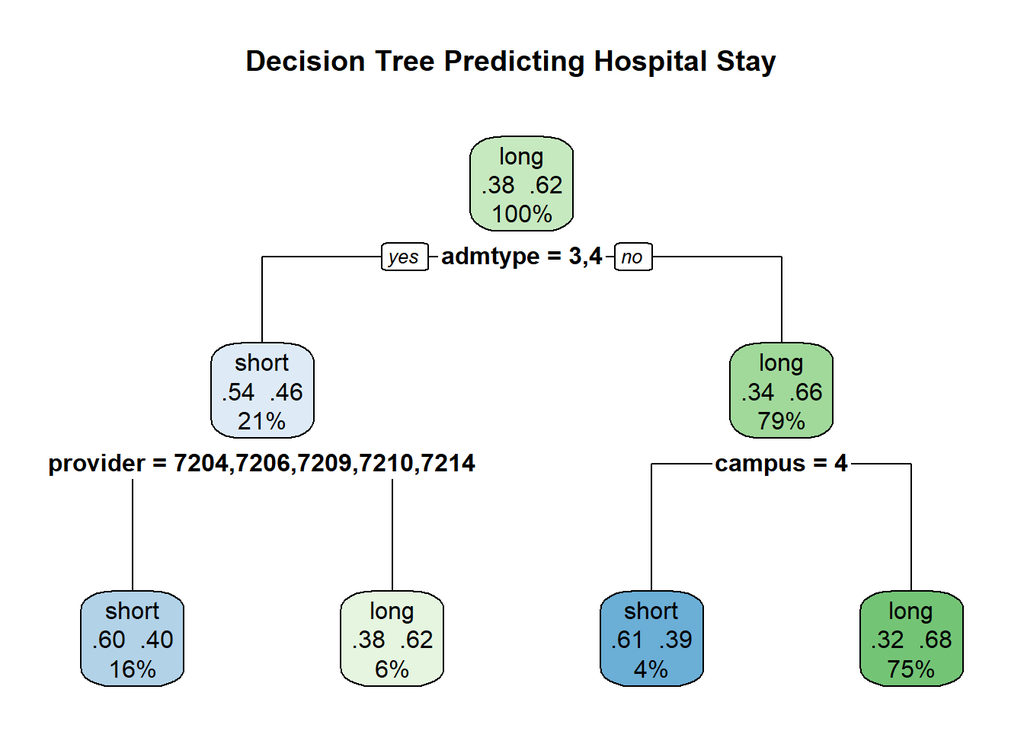

```r
set.seed(123)

tree_model2 <- rpart(
  target ~ .,
  data = train_data2,
  method = "class",
  control = rpart.control(cp = 0.01, minsplit = 20)
)

# plot decision tree
rpart.plot(
  tree_model2,
  main = "Decision Tree Predicting Hospital Stay",
  type = 2,
  extra = 104,
  fallen.leaves = TRUE
)
```

```r
# calculate variable importance
importance2 <- data.frame(
  Variable = names(tree_model2$variable.importance),
  Importance = as.numeric(tree_model2$variable.importance)
) %>%
  arrange(desc(Importance))

print(importance2)
```

```
##   Variable Importance
## 1  admtype 186.837428
## 2      age 103.843803
## 3   campus 102.722376
## 4 provider  69.091411
## 5 raceethn   3.435756
```

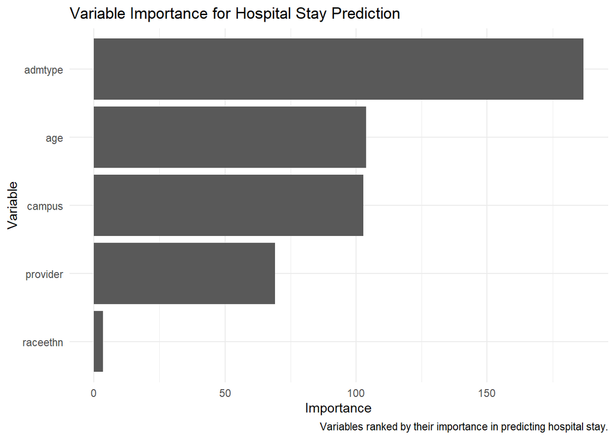

```r
# plot variable importance
ggplot(
  importance2,
  aes(x = reorder(Variable, Importance), y = Importance)
) +
  geom_col() +
  coord_flip() +
  labs(
    title = "Variable Importance for Hospital Stay Prediction",
    x = "Variable",
    y = "Importance",
    caption = "Variables ranked by their importance in predicting hospital stay."
  ) +
  theme_minimal()
```

```r
# five fold
trControl2 <- trainControl(
  method = "cv",
  number = 5
)

#decision tree

set.seed(123)

caret_tree2 <- train(
  target ~ .,
  data = train_data2,
  method = "rpart",
  trControl = trControl2,
  tuneLength = 10,
  metric = "Accuracy"
)

# display results
print(caret_tree2)
```

```
## CART
##
## 12754 samples
##     8 predictor
##     2 classes: 'short', 'long'
##
## No pre-processing
## Resampling: Cross-Validated (5 fold)
## Summary of sample sizes: 10203, 10203, 10203, 10204, 10203
## Resampling results across tuning parameters:
##
##   cp            Accuracy   Kappa
##   0.0006186843  0.6596362  0.21032201
##   0.0006599299  0.6613611  0.21238028
##   0.0010311404  0.6662219  0.20663180
##   0.0014435966  0.6671627  0.20638123
##   0.0019591668  0.6664571  0.20345190
##   0.0026809651  0.6663784  0.20416926
##   0.0043307899  0.6650454  0.19925327
##   0.0072179831  0.6629286  0.18731947
##   0.0120643432  0.6617524  0.18203874
##   0.0661992163  0.6324293  0.06456991
##
## Accuracy was used to select the optimal model using the largest value.
## The final value used for the model was cp = 0.001443597.
```

```r
# best tuning parameter
caret_tree2$bestTune
```

```
##            cp
## 4 0.001443597
```

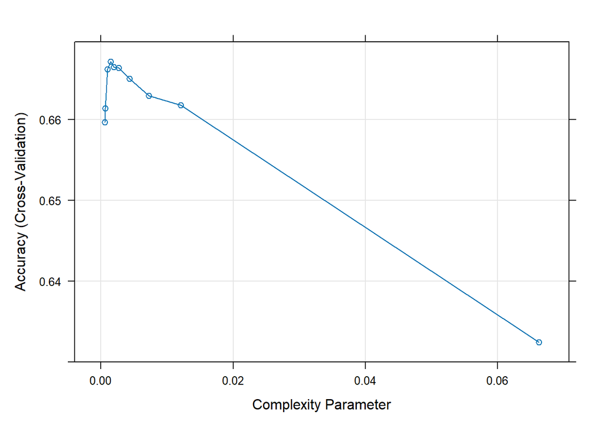

```r
# plot tuning results
plot(caret_tree2)
```

```r
# random forest

set.seed(123)

caret_forest2 <- train(
  target ~ .,
  data = train_data2,
  method = "ranger",
  trControl = trControl2,
  tuneLength = 5,
  metric = "Accuracy",
  importance = "impurity"
)

# display results
print(caret_forest2)
```

```
## Random Forest
##
## 12754 samples
##     8 predictor
##     2 classes: 'short', 'long'
##
## No pre-processing
## Resampling: Cross-Validated (5 fold)
## Summary of sample sizes: 10203, 10203, 10203, 10204, 10203
## Resampling results across tuning parameters:
##
##   mtry  splitrule   Accuracy   Kappa
##    2    gini        0.6463848  0.12369966
##    2    extratrees  0.6405047  0.09988548
##   14    gini        0.6448170  0.20674830
##   14    extratrees  0.6531279  0.21290009
##   26    gini        0.6243530  0.18116438
##   26    extratrees  0.6335263  0.19101663
##   38    gini        0.6179234  0.17162391
##   38    extratrees  0.6227070  0.18085503
##   50    gini        0.6155712  0.16877282
##   50    extratrees  0.6164342  0.17307152
##
## Tuning parameter 'min.node.size' was held constant at a value of 1
## Accuracy was used to select the optimal model using the largest value.
## The final values used for the model were mtry = 14, splitrule = extratrees
##  and min.node.size = 1.
```

```r
# best tuning parameters
caret_forest2$bestTune
```

```
##   mtry  splitrule min.node.size
## 4   14 extratrees             1
```

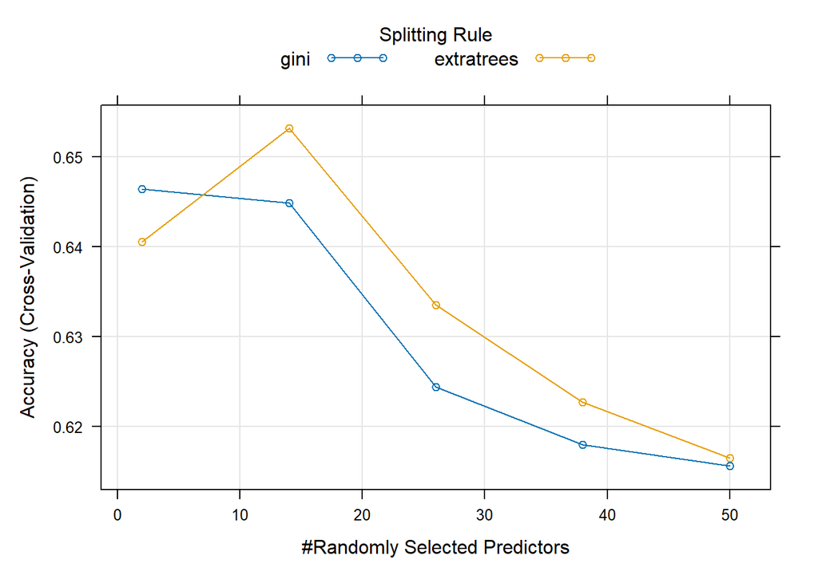

```r
# plot tuning results
plot(caret_forest2)
```